# Principal Component Analysis for Penguins

Throughout this document I am going to use the code `package::function()` so that you know which package produces each function. In general, this is unnecessary if you load the libraries above, but occasionally it is helpful is the libraries contain functions with the same names. This work is adapted from Allison Horst: https://github.com/allisonhorst/palmerpenguins/blob/master/vignettes/pca.Rmd

## Correlation Matrix

```r
data("penguins") #loads penguin data sets
```

```r
penguins_corr <- penguins %>%
  dplyr::select(body_mass_g, ends_with("_mm")) %>% #selects the columns we want
  corrr::correlate() %>% #calculate correlations
  corrr::rearrange() #Re-arrange a correlation data frame to group highly correlated variables closer together.
penguins_corr
```

```
# A tibble: 4 × 5
  term              flipper_length_mm body_mass_g bill_length_mm bill_depth_mm
  <chr>                         <dbl>       <dbl>          <dbl>         <dbl>
1 flipper_length_mm            NA           0.871          0.656        -0.584
2 body_mass_g                   0.871      NA              0.595        -0.472
3 bill_length_mm                0.656       0.595         NA            -0.235
4 bill_depth_mm                -0.584      -0.472         -0.235        NA
```

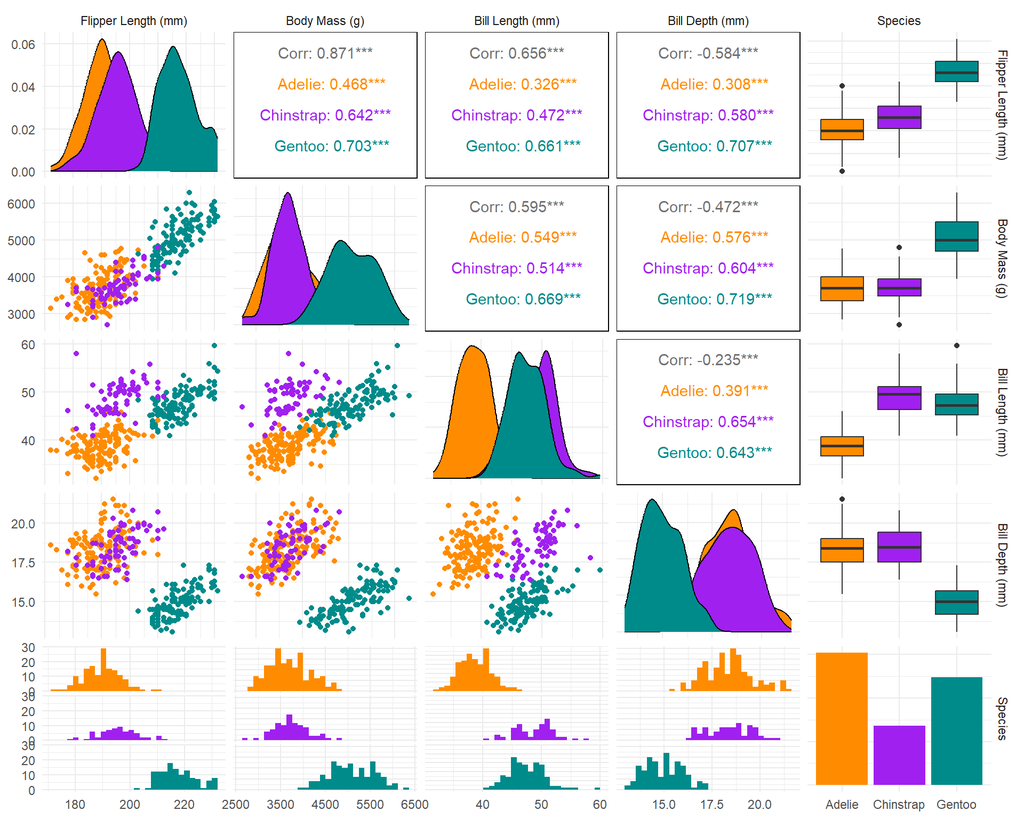

```r
penguins %>%
  select(species, body_mass_g, ends_with("_mm")) %>%
  GGally::ggpairs(aes(color = species),
                  columns = c("flipper_length_mm", "body_mass_g",
                              "bill_length_mm", "bill_depth_mm", "species"),
                  columnLabels = c("Flipper Length (mm)", "Body Mass (g)",
                                   "Bill Length (mm)", "Bill Depth (mm)",
                                   "Species")) +
  scale_color_manual(values = c("darkorange","purple","cyan4")) +
  scale_fill_manual(values = c("darkorange","purple","cyan4")) +
  scale_alpha(range = 0.5)
```

## Calculate the Principal Components

We’ll use the [recipes](https://recipes.tidymodels.org) package from [tidymodels](https://www.tidymodels.org) to perform a [principal component analysis (PCA)](https://en.wikipedia.org/wiki/Principal_component_analysis).

First, we’ll also use a few recipe steps to preprocess the data for PCA; namely, we need to:

- remove any `NA` values,
- center all predictors, and
- scale all predictors.

If you’ve never used the recipes package before, try [this article](https://www.tidymodels.org/start/recipes/) to get started.

```r
penguin_recipe <-
  recipes::recipe(~., data = penguins) %>% #starts the recipe of steps
  recipes::update_role(species, island, sex, year, new_role = "id") %>%  #retains the values in the data but not used in our evaluation
  recipes::step_naomit(all_predictors()) %>% #removes the NA
  recipes::step_normalize(all_predictors()) %>% #normalizes by mean/sd
  recipes::step_pca(all_predictors(), id = "pca") %>%  #calculates PCA
  prep() #retains the info for future analysis
```

```r
penguin_pca <-
  penguin_recipe %>%
  recipes::tidy(id = "pca") #create data set with model info
penguin_pca
```

```
# A tibble: 16 × 4
   terms                value component id
   <chr>                <dbl> <chr>     <chr>
 1 bill_length_mm     0.455   PC1       pca
 2 bill_depth_mm     -0.400   PC1       pca
 3 flipper_length_mm  0.576   PC1       pca
 4 body_mass_g        0.548   PC1       pca
 5 bill_length_mm    -0.597   PC2       pca
 6 bill_depth_mm     -0.798   PC2       pca
 7 flipper_length_mm -0.00228 PC2       pca
 8 body_mass_g       -0.0844  PC2       pca
 9 bill_length_mm    -0.644   PC3       pca
10 bill_depth_mm      0.418   PC3       pca
11 flipper_length_mm  0.232   PC3       pca
12 body_mass_g        0.597   PC3       pca
13 bill_length_mm     0.146   PC4       pca
14 bill_depth_mm     -0.168   PC4       pca
15 flipper_length_mm -0.784   PC4       pca
16 body_mass_g        0.580   PC4       pca
```

The `value` column here is the loading. For each component, the `value` tells us the linear combination of weights for each variable that contributes to that component.

This output is a tidy version of this using `stats::prcomp()`:

```r
penguins %>%
  dplyr::select(body_mass_g, ends_with("_mm")) %>%
  tidyr::drop_na() %>%
  scale() %>% #base R function to normalize
  prcomp() %>%  #base R function to calculate PCs
  .$rotation #extracts info that is relevant
```

```
                         PC1         PC2        PC3        PC4
body_mass_g        0.5483502 0.084362920  0.5966001  0.5798821
bill_length_mm     0.4552503 0.597031143 -0.6443012  0.1455231
bill_depth_mm     -0.4003347 0.797766572  0.4184272 -0.1679860
flipper_length_mm  0.5760133 0.002282201  0.2320840 -0.7837987
```

We can also apply the `recipes::tidy()` method to the output from `recipes::step_pca()` to examine how much variance each component accounts for:

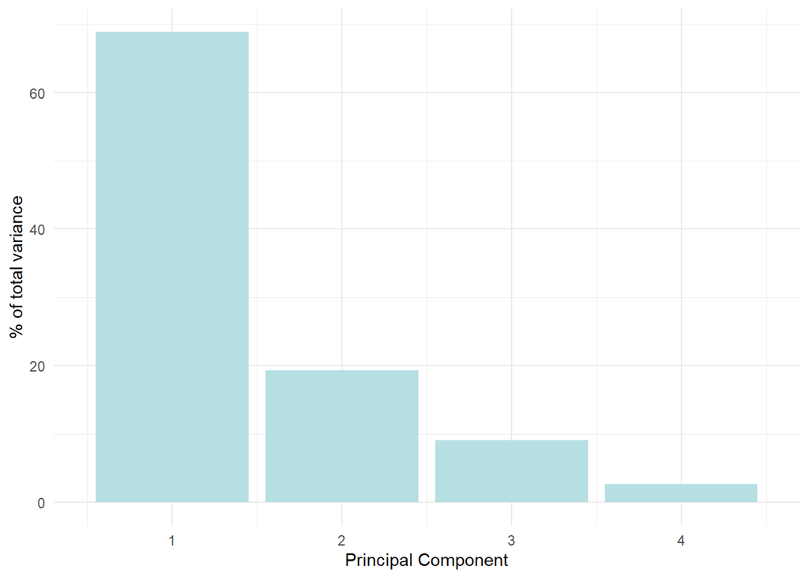

```r
penguin_recipe %>%
  recipes::tidy(id = "pca", type = "variance") %>%
  dplyr::filter(terms == "percent variance") %>%
  ggplot(aes(x = component, y = value)) +
  geom_col(fill = "#b6dfe2") +
  xlim(c(0.5, 4.5)) +
  ylab("% of total variance") +
  xlab("Principal Component")
```

We can also create a screeplot:

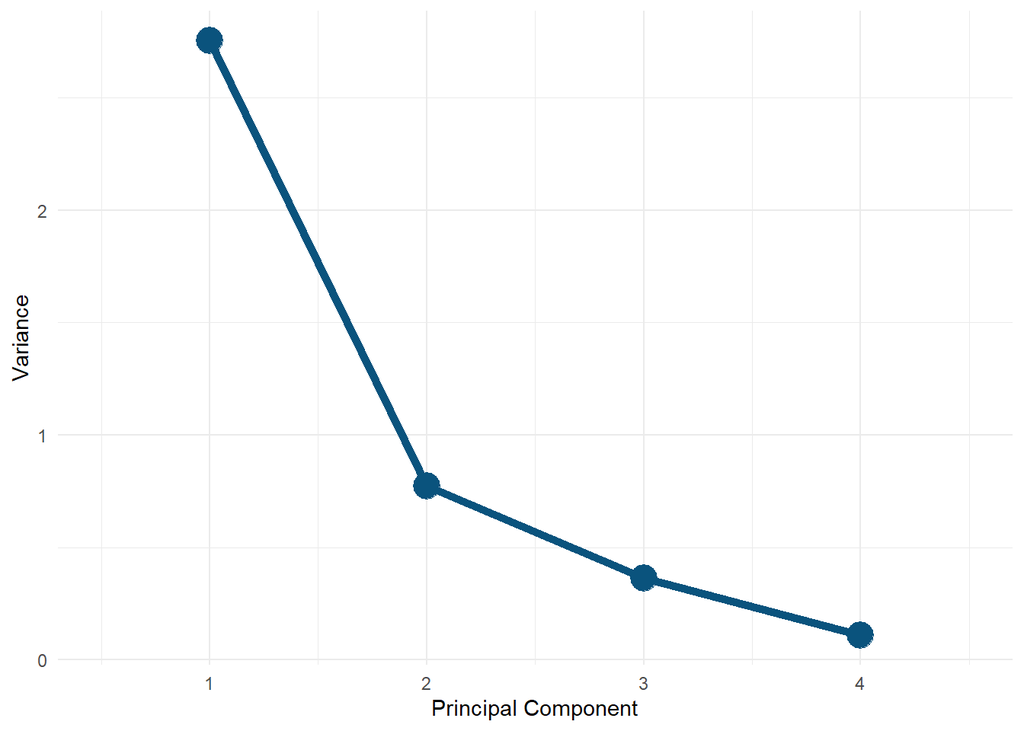

```r
penguin_recipe %>%
  recipes::tidy(id = "pca", type = "variance") %>%
  dplyr::filter(terms == "variance") %>%
  ggplot(aes(x = component, y = value)) +
  geom_point(color = "#0A537D", size = 6) +
  geom_line(color = "#0A537D", size = 2)+
  xlim(c(0.5, 4.5)) +
  ylab("Variance") +
  xlab("Principal Component")
```

Or overlay both:

```r
penguin_recipe %>%
  recipes::tidy(id = "pca", type = "variance") %>%
  dplyr::filter(terms == "variance") %>%
  summarise(total_var = sum(value))
```

```
# A tibble: 1 × 1
  total_var
      <dbl>
1         4
```

Here we can add a second axis - THE ONLY TIME TO ADD A SECOND AXIS IS WHEN THEY SCALE PROPORTIONALLY!

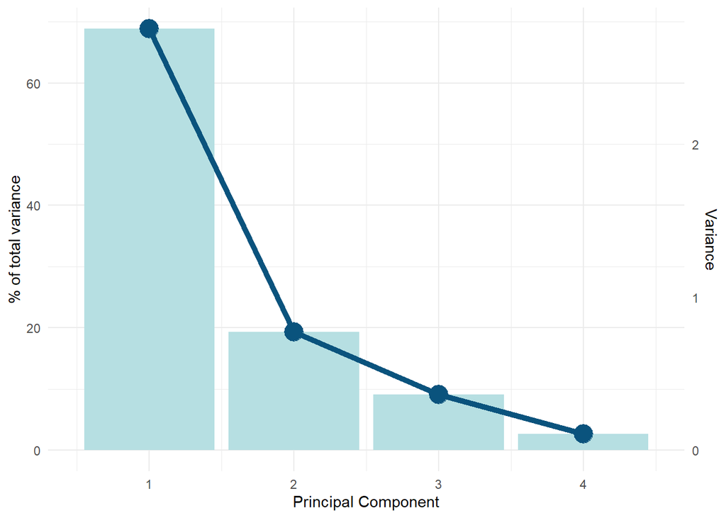

```r
penguin_recipe %>%
  recipes::tidy(id = "pca", type = "variance") %>%
  dplyr::filter(terms == "percent variance") %>%
  ggplot(aes(x = component, y = value)) +
  geom_col(fill = "#b6dfe2") +
  geom_point(color = "#0A537D", size = 6) +
  geom_line(color = "#0A537D", size = 2)+
  xlim(c(0.5, 4.5)) +
  ylab("% of total variance") +
  xlab("Principal Component") +
  scale_y_continuous(sec.axis = sec_axis(~ . *4/100, name = "Variance"))
```

## Plot PCA loadings

We can plot these loadings by principal component too, following [Julia Silge’s example](https://juliasilge.com/blog/cocktail-recipes-umap/):

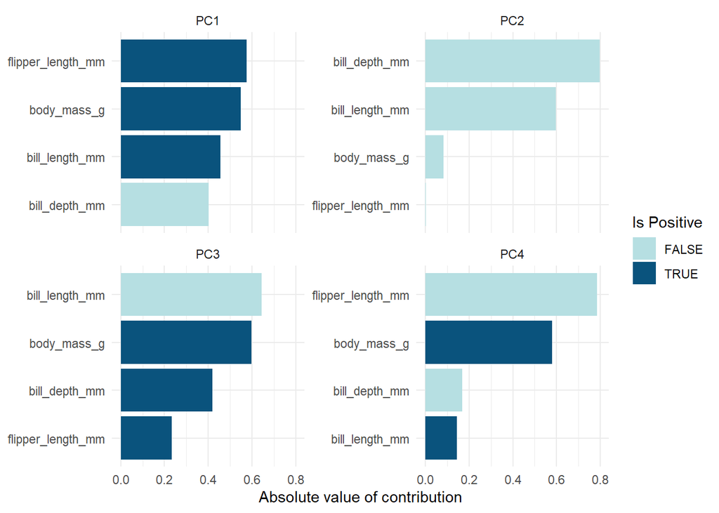

```r
penguin_pca %>%
  mutate(terms = tidytext::reorder_within(terms,
                                          abs(value),
                                          component)) %>%
  ggplot(aes(abs(value), terms, fill = value > 0)) +
  geom_col() +
  facet_wrap(~component, scales = "free_y") +
  tidytext::scale_y_reordered() +
  scale_fill_manual(values = c("#b6dfe2", "#0A537D")) +
  labs(
    x = "Absolute value of contribution",
    y = NULL, fill = "Is Positive"
  )
```

## Plot PCA loadings + scores

We have the PCA loadings in `penguin_pca`. But we need them in a wide format now for plotting.

```r
# get pca loadings into wider format
pca_wider <- penguin_pca %>%
  tidyr::pivot_wider(names_from = component, id_cols = terms)
pca_wider
```

```
# A tibble: 4 × 5
  terms                PC1      PC2    PC3    PC4
  <chr>              <dbl>    <dbl>  <dbl>  <dbl>
1 bill_length_mm     0.455 -0.597   -0.644  0.146
2 bill_depth_mm     -0.400 -0.798    0.418 -0.168
3 flipper_length_mm  0.576 -0.00228  0.232 -0.784
4 body_mass_g        0.548 -0.0844   0.597  0.580
```

We also need to go back to our prepped penguin recipe, `penguins_recipe`, and `recipes::juice()` it to get the PCA scores back.

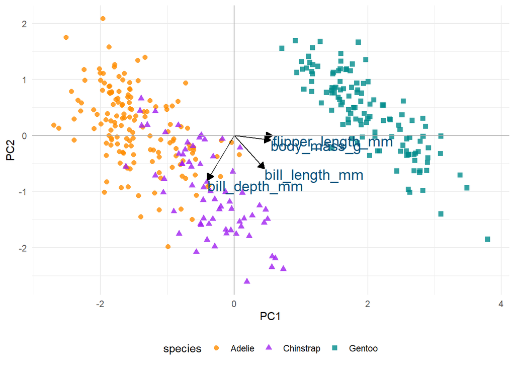

```r
# define arrow style
arrow_style <- arrow(length = unit(.1, "inches"),
                     type = "closed")
pca_plot <-
  recipes::juice(penguin_recipe) %>%
  ggplot(aes(PC1, PC2)) +
  geom_point(aes(color = species, shape = species),
             alpha = 0.8,
             size = 2) +
  scale_colour_manual(values = c("darkorange","purple","cyan4")) +
  theme(legend.position = "bottom")


pca_plot +
  geom_segment(data = pca_wider,
               aes(xend = PC1, yend = PC2),
               x = 0,
               y = 0,
               arrow = arrow_style) +
  geom_text(data = pca_wider,
            aes(x = PC1, y = PC2, label = terms),
            hjust = 0,
            vjust = 1,
            size = 5,
            color = '#0A537D') +
  geom_hline(yintercept = 0, color = "darkgrey") +
  geom_vline(xintercept = 0, color = "darkgrey")
```

In the above plot, you can see a lot!

First, if you focus on the x-axis showing us the first principal component, you can see that flipper length and body mass are very important (confirming what we saw in the above bar chart). Along this dimension, Gentoo penguins stand out clearly from the other two species. We can confirm this looking at summary statistics:

```r
penguins %>%
  group_by(species) %>%
  summarize(across(c(flipper_length_mm, body_mass_g),
                   mean,
                   na.rm = TRUE))
```

```
# A tibble: 3 × 3
  species   flipper_length_mm body_mass_g
  <fct>                 <dbl>       <dbl>
1 Adelie                 190.       3701.
2 Chinstrap              196.       3733.
3 Gentoo                 217.       5076.
```

We can see this with a simple scatterplot:

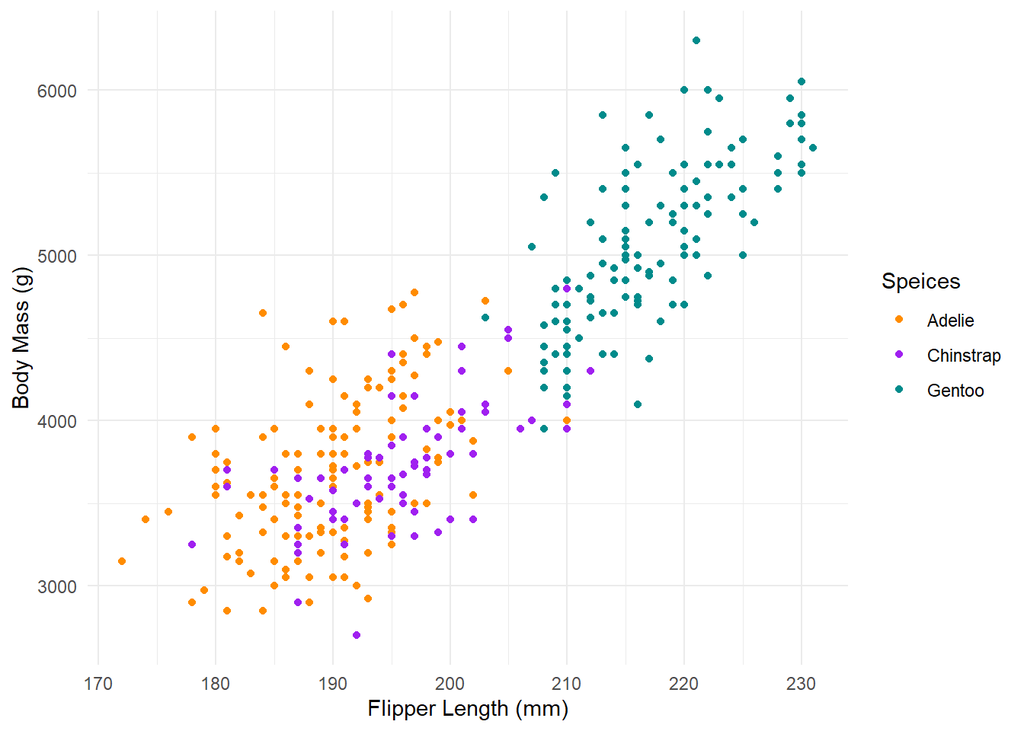

```r
ggplot(penguins, aes(x = flipper_length_mm, y = body_mass_g, color = species)) +
  geom_point() +
 scale_colour_manual(values = c("darkorange","purple","cyan4")) +
  labs(x = "Flipper Length (mm)",
       y = "Body Mass (g)",
       color = "Speices")
```

Let’s do the same thing for principal component 2 and 3.

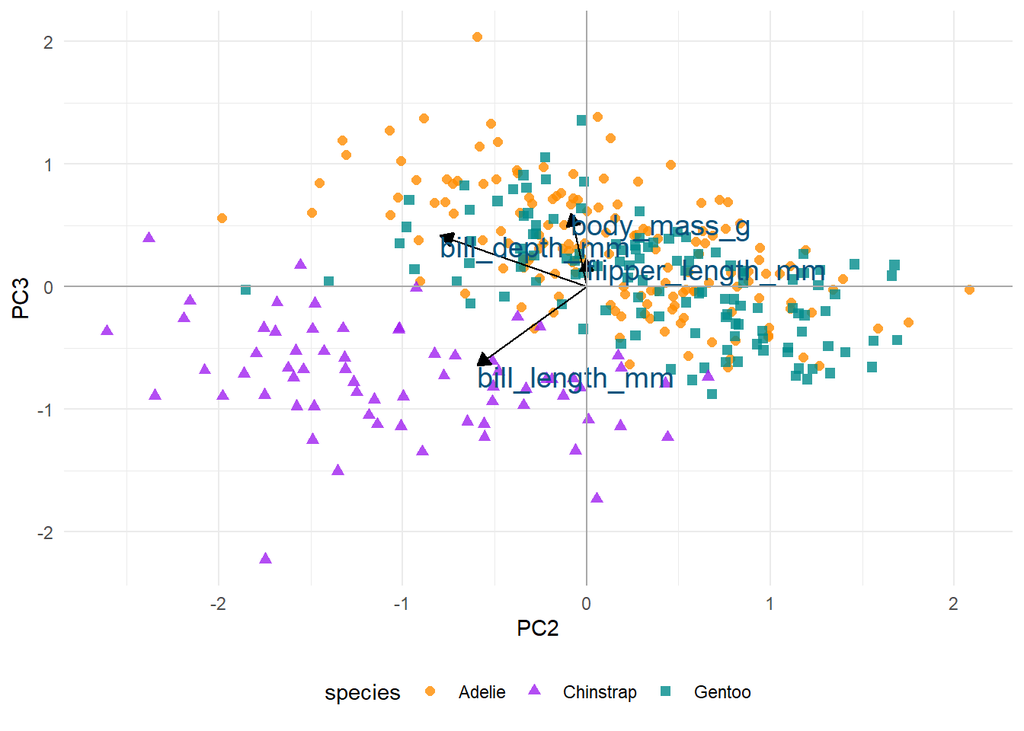

```r
pca_plot %+%
  aes(PC2, PC3) +
  geom_segment(data = pca_wider,
               aes(xend = PC2, yend = PC3),
               x = 0,
               y = 0,
               arrow = arrow_style) +
  geom_text(data = pca_wider,
            aes(x = PC2, y = PC3, label = terms),
            hjust = 0,
            vjust = 1,
            size = 5,
            color = '#0A537D') +
  geom_hline(yintercept = 0, color = "darkgrey") +
  geom_vline(xintercept = 0, color = "darkgrey")
```

We see again that PC2 seems most associated with our bill size variables, `bill_length_mm` and `bill_depth_mm`. But now we can see more clearly that this dimension seems to separate Chinstrap penguins from the other two species. We can confirm this by glancing at summary statistics again by species:

```r
penguins %>%
  group_by(species) %>%
  summarize(across(c(bill_depth_mm, bill_length_mm),
                   mean,
                   na.rm = TRUE))
```

```
# A tibble: 3 × 3
  species   bill_depth_mm bill_length_mm
  <fct>             <dbl>          <dbl>
1 Adelie             18.3           38.8
2 Chinstrap          18.4           48.8
3 Gentoo             15.0           47.5
```

We can see this with a simple scatterplot too:

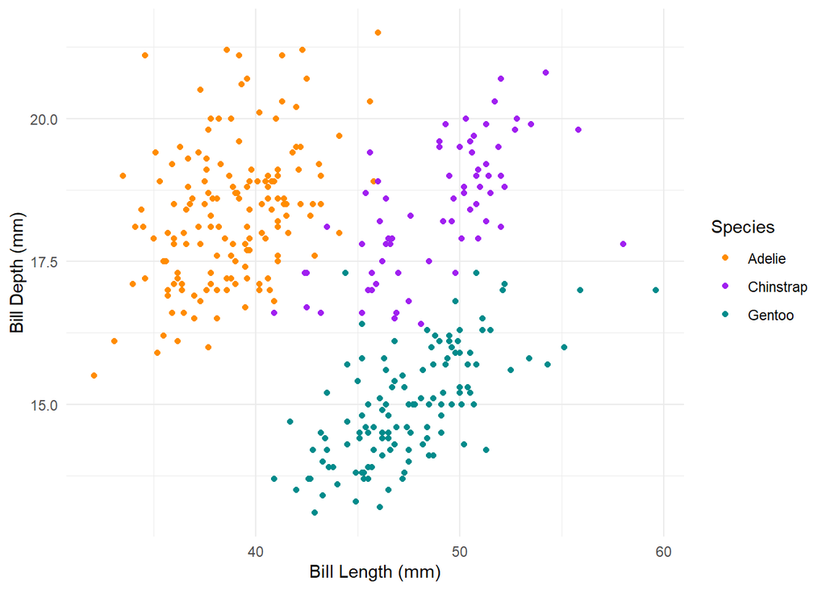

```r
ggplot(penguins, aes(x = bill_length_mm, y = bill_depth_mm, color = species)) +
  geom_point() +
  scale_colour_manual(values = c("darkorange","purple","cyan4"))  +
  labs(x = "Bill Length (mm)", y = "Bill Depth (mm)",
       color = "Species")
```

This is actually a pretty neat scatterplot—it highlights a perfect example of why you’d need the combination of two variables to differentiate between these three species. Comparing distributions for any single variable only differentiates one species from the other two![^1]

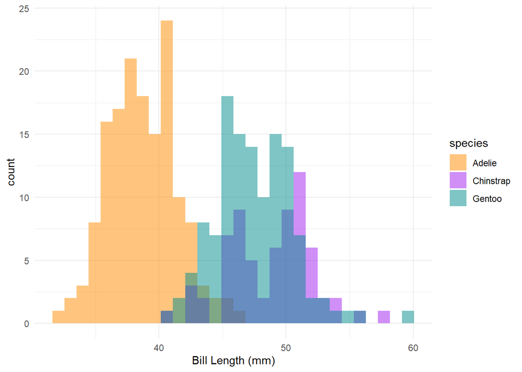

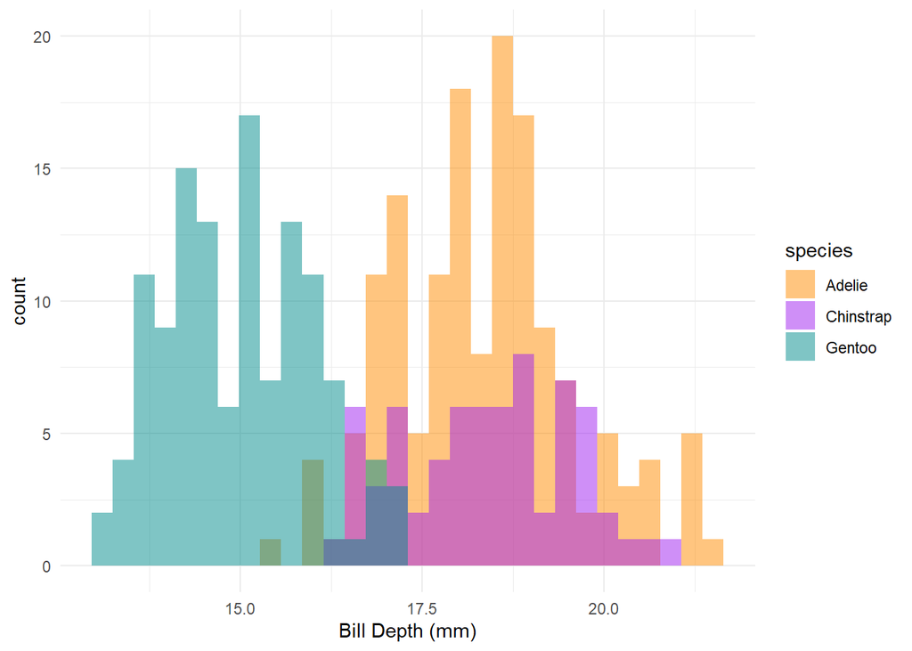

```r
ggplot(data = penguins, aes(x = bill_length_mm)) +
  geom_histogram(aes(fill = species), alpha = 0.5, position = "identity") +
  scale_fill_manual(values = c("darkorange","purple","cyan4"))  +
  labs(x = "Bill Length (mm)")

ggplot(data = penguins, aes(x = bill_depth_mm)) +
  geom_histogram(aes(fill = species), alpha = 0.5, position = "identity") +
  scale_fill_manual(values = c("darkorange","purple","cyan4"))  +
  labs(x = "Bill Depth (mm)")
```

## Summary

So, Gentoos appear to just be giants, compared to the Adelie and Chinstrap penguins. While Adelie and Chinstraps are similar size-wise as measured by flipper length and body mass, Chinstraps seem to have longer bills and Adelie penguins have stubbier bills (a pug-gein, if you will?). And Gentoos, despite being large overall, have flatter bills than either of the other two species.

## Other PCA resources

- Michael Friendly’s [multivariate palmerpenguins analysis](https://rpubs.com/friendly/penguin-biplots)
- Julia Silge’s [PCA and UMAP with tidymodels and #TidyTuesday cocktail recipes](https://juliasilge.com/blog/cocktail-recipes-umap/)

## Footnotes

[^1]: this is also a great example Simpson’s paradox, see `vignette("examples")`